# GEOG 6000 Lab 10 Geostatistics 2

## Indicator simulation

The simulation approach can also be used for indicator interpolation. As in the previous example, we simply reuse the `krige()` function. In addition to the `nsim` parameter, we include a parameter `indicators=TRUE` to perform indicator kriging. In this case, rather than each simulation estimating a probability at each new location, the method estimates a binary value (presence or absence) by drawing from a binomial distribution. To simulate 6 realizations of the distribution of soil class 1:

```r
s1.sis <- krige(I(soil == 1) ~ 1,
                meuse,
                meuse_grid,
                s1_vgm,
                nsim = 6,
                indicators = TRUE,
                nmax = 40)
```

```
drawing 6 GLS realisations of beta...
[using conditional indicator simulation]
```

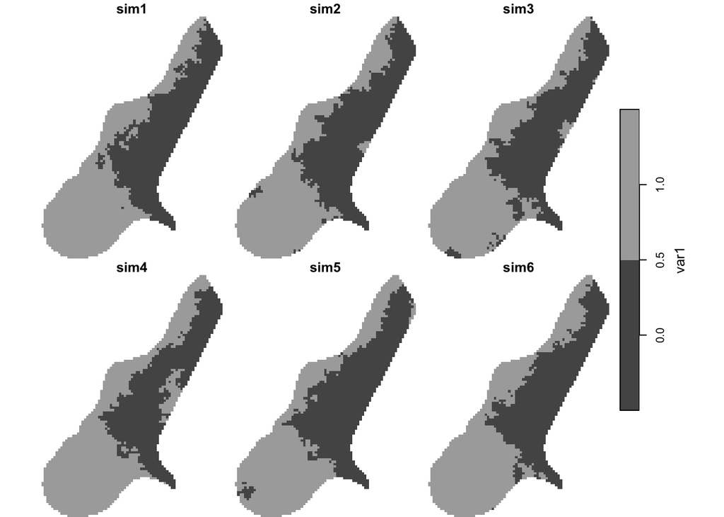

```r
plot(s1.sis)
```

```r
s1.sim <- krige(I(soil == 1) ~ 1,
                meuse,
                meuse_grid,
                s1_vgm,
                nsim = 1000,
                indicators = TRUE,
                nmax = 40)
```

```
drawing 1000 GLS realisations of beta...
[using conditional indicator simulation]
```

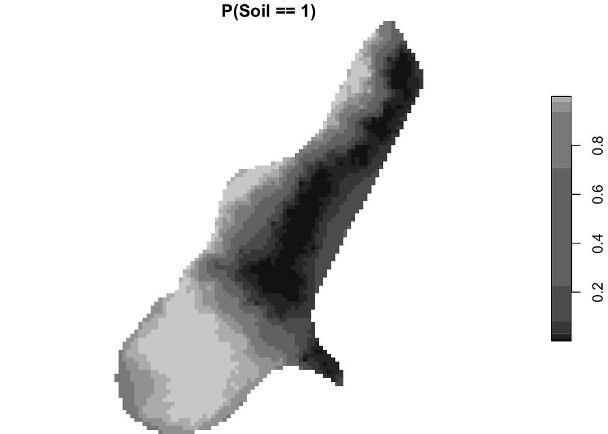

```r
s1.prob <- st_apply(s1.sim, c(1,2), sum) / 1000

plot(s1.prob, main = "P(Soil == 1)")
```

In contrast to the indicator kriging, the output from this function provides true probabilities of presence, constrained to the range [0,1].

# Exercise

1. The compressed file *mwozone.zip* contains measurements of ground ozone concentration in the midwestern US for June 20, 1987 in the shapefile *ozone.shp*. The goal of this exercise is use this data to produce a map showing the probability that a certain threshold (100 ppb) was passed on that date. You can do this using either indicator kriging or indicator simulation, using the examples provided in the lab. You are free to approach this in your own way, but you will need to provide at least the following:
- A map of ozone concentrations at the measurement stations
- A plot of the sample variogram describing the spatial structure of the condition you want to interpolate (ozone $>$ 100 ppb), and a brief description of the spatial structure you observe
- A variogram model fitted to this (as a figure), and give the model chosen, the sill, range and nugget value (if appropriate)
- A map of predicted probabilities of passing 100 ppb ozone. In order to do this, you will need to create a longitude/latitude grid for interpolation. See code below for how to do this simply in R
- A brief description of the spatial pattern shown on the interpolated map — what do you think the higher probabilities relate to?

## Code to add shapefiles

It may help to add other shapefiles to your maps for this exercise. The following code assumes that you have read in the ozone shapefile to a `sf` object called `ozone_sf`, and adds state outlines, lakes and cities using the [Natural Earth datasets](https://www.naturalearthdata.com). The example here plots out the ozone concentrations, but you can adapt this pretty easily for the predicted values you obtain. Note that to run this code, you will need to make sure the **tmap** package is installed and download and unzip the following files from Canvas:

- *ne_50m_admin_1_states_provinces.zip*
- *ne_50m_lakes.zip*
- *ne_50m_populated_places.zip*

```r
ozone_sf <- st_read("./data/mwozone/ozone.shp")
st_crs(ozone_sf) <- 4326
```

```r
## Read data
states <- st_read("./data/ne_50m_admin_1_states_provinces/ne_50m_admin_1_states_provinces_shp.shp", quiet = TRUE)
lakes <- st_read("./data/ne_50m_lakes/ne_50m_lakes.shp", quiet = TRUE)
places <- st_read("./data/ne_50m_populated_places/ne_50m_populated_places.shp", quiet = TRUE)
```

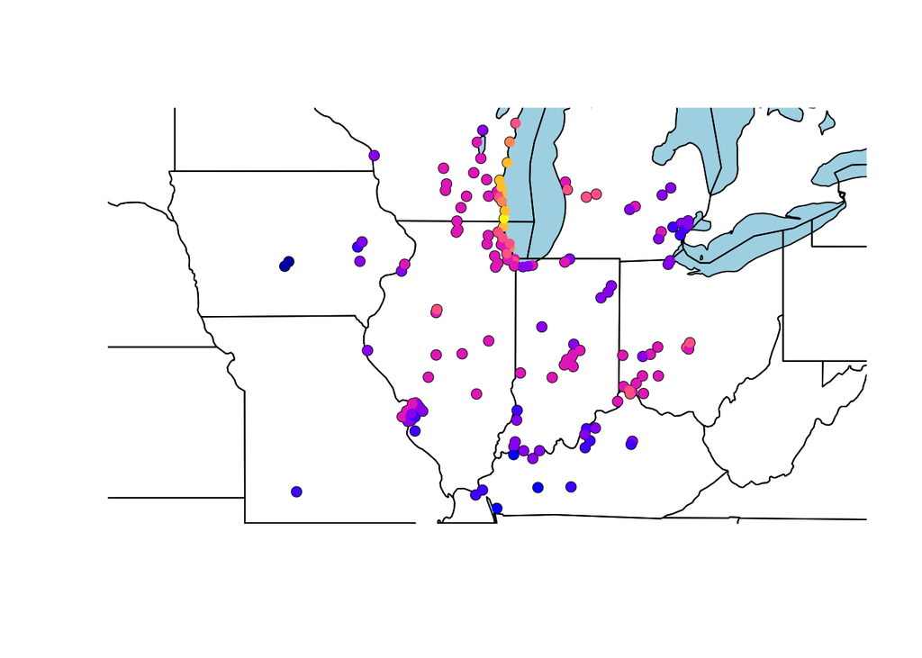

```r
plot(st_geometry(ozone_sf), reset = FALSE)
plot(st_geometry(lakes), reset = FALSE, add = TRUE, col = "lightblue")
plot(st_geometry(states), reset = FALSE, add = TRUE)
plot(ozone_sf["ozone"], add = TRUE, pch = 16)
```

Better plots with multiple layer can be made by using the `geom_sf` function from **ggplot2**:

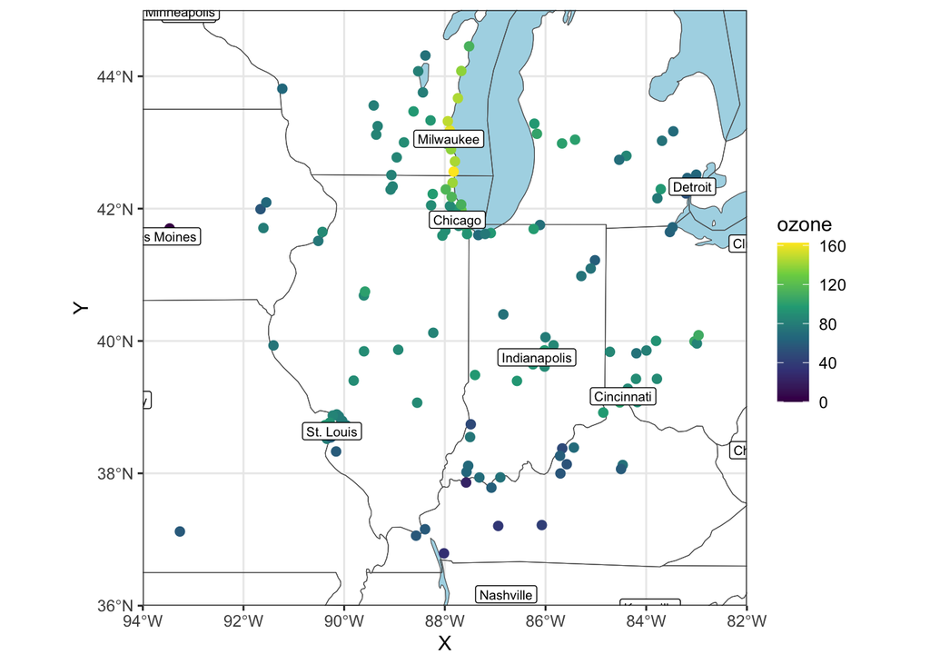

```r
places <- cbind(places, st_coordinates(st_centroid(places)))

ggplot() +
  geom_sf(data = lakes, fill = "lightblue") +
  geom_sf(data = states, fill = NA) +
  geom_sf(data = ozone_sf, aes(col = ozone), size = 2) +
  scale_color_viridis_c() +
  geom_label(data = places, aes(X, Y, label = NAME), size = 2.5) +
  coord_sf(xlim = c(-94, -82), ylim = c(36, 45), expand = FALSE) +
  theme_bw()
```

Alternatively you can use the **tmap** package to make a better plot:

```
[tip] Consider a suitable map projection, e.g. by adding `+ tm_crs("auto")`.
```

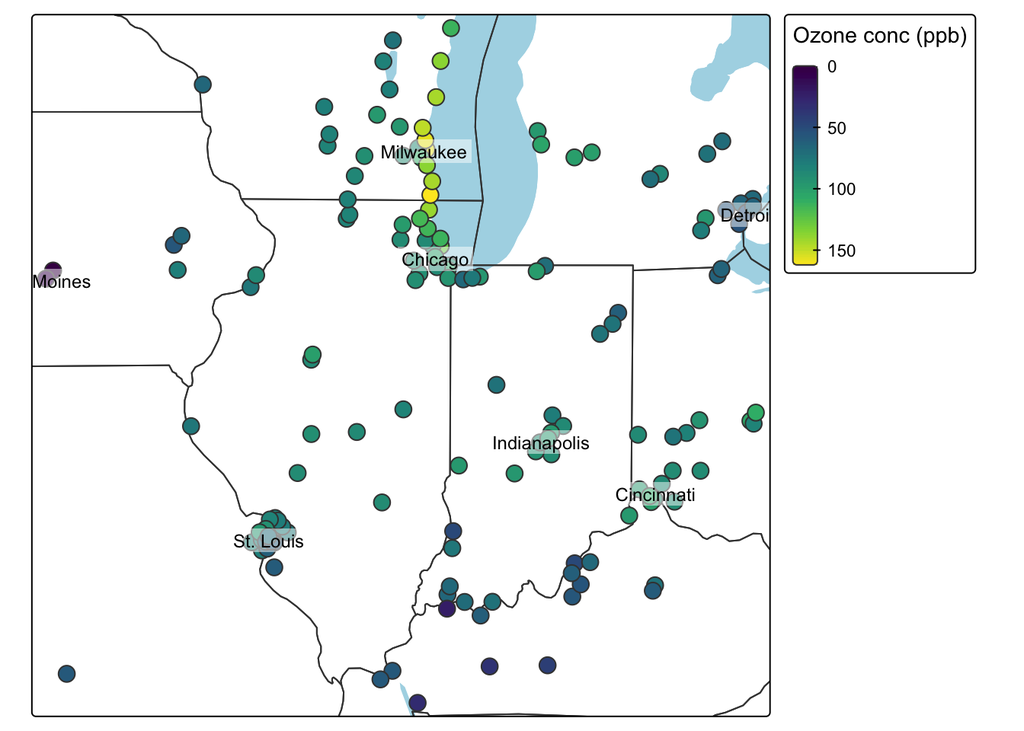

```r
library(tmap)

mybbox <- st_bbox(ozone_sf)
tm_shape(lakes, bbox = mybbox) +
  tm_fill("lightblue") +
  tm_shape(states) +
  tm_borders() +
  tm_shape(ozone_sf) +
  tm_symbols(fill = "ozone", size = 0.75,
             fill.scale = tm_scale_continuous(values = "viridis"),
    fill.legend = tm_legend(title = "Ozone conc (ppb)")) +
  tm_shape(places) +
  tm_labels("NAME", size = 0.75, bgcol = 'white', bgcol_alpha = 0.5)
```

## Code to make a prediction grid

```r
pred.grid <- st_as_stars(mybbox,
                         xlim = c(-94, -82),
                         ylim = c(36, 45),
                         dx = 0.1,
                         dy = 0.1)

st_crs(pred.grid) <- 4326
```